# Wykorzystanie pakietu nonprobsvy (2023.12.08)

Author

Maciej Beręsewicz & Łukasz Chrostowski

# Informacje

Szkolenie sfinansowane w ramach projektu “Statystyka cudzoziemców bez spisu powszechnego - jakość, integracja danych i estymacja” (opis) finansowanego z grantu Narodowego Centrum Nauki OPUS 20 (2020/39/B/HS4/00941).

# Instalacje i pakiety

Instalujemy pakiet `remotes`.

```r
install.packages("remotes") ## do instalacji pakietu nonprobsvy
install.packages("ggplot2") ## do wizualiacji
install.packages("survey") ## do estymacji na podstawie prób losowych
remotes::install_github("ncn-foreigners/nonprobsvy")
```

Ładujemy pakiet `nonprobsvy`.

```r
library(nonprobsvy) ## do prób nielosowych
library(survey) ## do badania popyt na pracę
library(ggplot2) ## do wizualizacji
```

# Dane na szkolenie

Zbiory danych znajdują się w folderze `data-raw/`:

- plik `popyt.csv` – zawiera zanonimizowane dane o podmiotach posiadających przynajmniej jedno wolne miejsce pracy z badania [Popyt na pracę](https://stat.gov.pl/obszary-tematyczne/rynek-pracy/popyt-na-prace/) (PnP) pozyskane przez Instytut Informatyki i Gospodarki Ilościowej UEP.
- plik `cbop.csv` – zawiera zanonimizowane dane podmiotów, będących w populacji badania PnP, z [Centralnej Bazy Ofert Pracy](https://oferty.praca.gov.pl/portal/index.cbop#/listaOfert) pobrane przez CBOP API.

Zbiory danych zawierają następujące kolumny:

- `id_jednostki` – unikalny identyfikator jednostki,
- `sektor` - 0=publiczny, 1=prywatny,
- `pkd` - sekcje pkd (od C do S; sekcje połączone: D i E, K i L, R i S),
- `woj` - województwo
- `waga` (tylko `popyt`) – waga finalna ustalona w ramach badania PnP,
- `jedna_zmiana` (tylko `cbop`) – czy podmiot zatrudnia osoby na jedną zmianę (na podstawie zmiennej `kodZmianowości`, więcej na [CBOP dla integratorów](https://oferty.praca.gov.pl/portal/index.cbop#/dlaInt)).

Wczytujemy dane

```r
popyt <- read.csv("../data-raw/popyt.csv",
                  colClasses = c("character", "numeric", rep("character", 3), "numeric"))
head(popyt)
```

| id_jednostki | sektor | klasa | pkd | woj | waga |
| --- | --- | --- | --- | --- | --- |
| a9cc990df6a99ab215a1bc13f51d4825c7d52d18 | 0 | D | O | 14 | 1 |
| c9dbaf50890165ebe810aa770de0e9df903dc35b | 0 | D | O | 24 | 6 |
| 718e0bba42bcec6ed98f9690db6d26cb7b93c880 | 0 | D | R.S | 14 | 1 |
| 532a1879a692b9d7bbb7282ba757d028156ef341 | 0 | D | R.S | 14 | 1 |
| 0b6b623fa45e257284a3049d097af322841337e3 | 0 | D | R.S | 22 | 1 |
| c855a825e80866c00c7513721d5fcb38929f3cd6 | 0 | S | R.S | 26 | 1 |

Deklarujemy obiekt `svydesign`. Dla uproszczenie zakłdamy, że warstwy określone są przez 3 zmienne: `klasa`, `pkd` i `woj`. W praktyce schemat losowania jest troszkę inny (por. [Zeszyt metodologiczny badania PnP](https://stat.gov.pl/obszary-tematyczne/rynek-pracy/popyt-na-prace/zeszyt-metodologiczny-popyt-na-prace,3,1.html)).

```r
popyt_svy <- svydesign(ids = ~1,  ## losujemy jednostki, a nie zespoły
                       weights = ~waga,  ## waga finalna
                       strata = ~ klasa + pkd + woj,  ## warstwy
                       data = popyt) ## dane

svytotal(~klasa, popyt_svy)
```

```
       total      SE
klasaD  8561  890.34
klasaM 29551 2123.03
klasaS 13758 1199.67
```

```r
cbop <- read.csv("../data-raw/cbop.csv",
                 colClasses = c("character", "numeric", rep("character", 3), "logical")
                 )
head(cbop)
```

| id_jednostki | sektor | klasa | pkd | woj | jedna_zmiana |
| --- | --- | --- | --- | --- | --- |
| 7fddce081cbb1dd5da072e1683e9bfd20acab593 | 0 | D | P | 30 | FALSE |
| 3d40ca689a4dca7d774981dc7db408301bf7f192 | 0 | D | O | 14 | TRUE |
| 2b5a57b0c2f03c2b252e559bcd77d52789d33d9c | 0 | D | O | 04 | TRUE |
| f2b18f5ef4386e70206d64810b5d3b7e0654918b | 0 | D | O | 24 | TRUE |
| bf17263f8fa3a9ff12d7ff60c10c4e426aeeb36e | 0 | D | O | 04 | TRUE |
| 10fe847b7d19284e9e310105c5acfaf8f1ccbc37 | 1 | D | C | 28 | FALSE |

Odsetek podmiotów zatrudniających na jedną zmianę na podstawie danych CBOP bez korekty wynosi: 66.05.

# Estymator IPW

## Standardowy estymator

```r
est1_logit <- nonprob(
  selection = ~ woj + sektor + pkd + klasa,
  target = ~ jedna_zmiana,
  svydesign = popyt_svy,
  data = cbop,
  method_selection = "logit"
)

est1_probit <- nonprob(
  selection = ~ woj + sektor + pkd + klasa,
  target = ~ jedna_zmiana,
  svydesign = popyt_svy,
  data = cbop,
  method_selection = "probit"
)

est1_cloglog <- nonprob(
  selection = ~ woj + sektor + pkd + klasa,
  target = ~ jedna_zmiana,
  svydesign = popyt_svy,
  data = cbop,
  method_selection = "cloglog"
)

est_ipw_standard <- rbind(cbind(est1_logit$output, est1_logit$confidence_interval),
                          cbind(est1_probit$output, est1_probit$confidence_interval),
                          cbind(est1_cloglog$output, est1_cloglog$confidence_interval))
est_ipw_standard$est <- "ipw"
rownames(est_ipw_standard) <- NULL
est_ipw_standard
```

| mean | SE | lower_bound | upper_bound | est |
| --- | --- | --- | --- | --- |
| 0.7083228 | 0.0106342 | 0.6874801 | 0.7291656 | ipw |
| 0.7088042 | 0.0120799 | 0.6851281 | 0.7324803 | ipw |
| 0.7084872 | 0.0101165 | 0.6886593 | 0.7283151 | ipw |

Strukura obiektu

```r
str(est1_logit,1)
```

```
List of 13
 $ call               : language nonprob(data = cbop, selection = ~woj + sektor + pkd + klasa, target = ~jedna_zmiana,      svydesign = popyt_svy,| __truncated__
 $ X                  : num [1:15867, 1:32] 1 1 1 1 1 1 1 1 1 1 ...
  ..- attr(*, "dimnames")=List of 2
 $ y                  :List of 1
 $ prob               : num [1:15867] 0.497 0.101 0.376 0.148 0.376 ...
 $ weights            : num [1:9344] 2.01 9.92 2.66 6.77 2.66 ...
 $ control            :List of 2
 $ output             :'data.frame':    1 obs. of  2 variables:
 $ SE                 :'data.frame':    1 obs. of  2 variables:
 $ confidence_interval:'data.frame':    1 obs. of  2 variables:
 $ nonprob_size       : int 9344
 $ prob_size          : int 6523
 $ pop_size           : Named num 52898
  ..- attr(*, "names")= chr "pop_size"
 $ selection          :List of 13
 - attr(*, "class")= chr [1:2] "nonprobsvy" "nonprobsvy_ipw"
```

Informacje o modelu regresji logistycznej będącym podstawą estymatora IPW.

```r
str(est1_logit$selection,1)
```

```
List of 13
 $ coefficients     : Named num [1:32] -0.653 0.838 0.2 0.105 -0.158 ...
  ..- attr(*, "names")= chr [1:32] "(Intercept)" "woj04" "woj06" "woj08" ...
 $ std_err          : Named num [1:32] 0.075 0.0712 0.0725 0.0891 0.0641 ...
  ..- attr(*, "names")= chr [1:32] "(Intercept)" "woj04" "woj06" "woj08" ...
 $ residuals        : num [1:15867] -0.101 -0.148 -0.219 -0.219 -0.385 ...
 $ variance         : num 0.376
 $ fitted_values    : num [1:15867] 0.497 0.101 0.376 0.148 0.376 ...
 $ link             :List of 16
  ..- attr(*, "class")= chr "method_selection"
 $ linear_predictors: num [1:15867] -2.188 -1.753 -1.272 -1.272 -0.468 ...
 $ aic              : num 43895
 $ weights          : num [1:9344] 2.01 9.92 2.66 6.77 2.66 ...
 $ prior.weights    : num [1:9344] 1 1 1 1 1 1 1 1 1 1 ...
 $ formula          :Class 'formula'  language ~woj + sektor + pkd + klasa
  .. ..- attr(*, ".Environment")=<environment: R_GlobalEnv>
 $ df_residual      : int 15835
 $ log_likelihood   : num -21915
```

Metoda summary

```r
summary(est1_logit)
```

```
Call:
nonprob(data = cbop, selection = ~woj + sektor + pkd + klasa,
    target = ~jedna_zmiana, svydesign = popyt_svy, method_selection = "logit")

-------------------------
Estimated population mean: 0.7083 with overall std.err of: 0.01063
And std.err for nonprobability and probability samples being respectively:
0.0063 and 0.008567

95% Confidence inverval for popualtion mean:
             lower_bound upper_bound
jedna_zmiana   0.6874801   0.7291656


Based on: Inverse probability weighted method
For a population of estimate size: 52898.13
Obtained on a nonprobability sample of size: 9344
With an auxiliary probability sample of size: 6523
-------------------------

Regression coefficients:
-----------------------
For glm regression on selection variable:
            Estimate Std. Error z value  P(>|z|)
(Intercept) -0.65278    0.07498  -8.706  < 2e-16 ***
woj04        0.83780    0.07121  11.765  < 2e-16 ***
woj06        0.19954    0.07245   2.754  0.00589 **
woj08        0.10481    0.08911   1.176  0.23950
woj10       -0.15756    0.06408  -2.459  0.01393 *
woj12       -0.60987    0.06029 -10.115  < 2e-16 ***
woj14       -0.84150    0.05419 -15.530  < 2e-16 ***
woj16        0.76386    0.08660   8.821  < 2e-16 ***
woj18        1.17811    0.07142  16.495  < 2e-16 ***
woj20        0.22252    0.09261   2.403  0.01627 *
woj22       -0.03753    0.06039  -0.621  0.53438
woj24       -0.40670    0.05474  -7.430 1.09e-13 ***
woj26        0.20287    0.08489   2.390  0.01685 *
woj28        0.57863    0.06797   8.513  < 2e-16 ***
woj30       -0.61021    0.05908 -10.328  < 2e-16 ***
woj32        0.32744    0.06957   4.706 2.52e-06 ***
```

[output cut: 17 more lines]

```
Signif. codes:  0 '***' 0.001 '**' 0.01 '*' 0.05 '.' 0.1 ' ' 1
-------------------------

Weights:
   Min. 1st Qu.  Median    Mean 3rd Qu.    Max.
  1.169   2.673   4.333   5.661   7.178  49.951
-------------------------

Residuals:
   Min. 1st Qu.  Median    Mean 3rd Qu.    Max.
-0.8552 -0.2308  0.5393  0.3080  0.7987  0.9800

AIC: 43894.82
BIC: 44140.32
Log-Likelihood: -21915.41 on 15835 Degrees of freedom
```

## Estymator kalibrowany

```r
est2_logit <- nonprob(
  selection = ~ woj + sektor + pkd + klasa,
  target = ~ jedna_zmiana,
  svydesign = popyt_svy,
  data = cbop,
  method_selection = "logit",
  control_selection = controlSel(h = 1, est_method_sel = "gee")
)

est2_probit <- nonprob(
  selection = ~ woj + sektor + pkd + klasa,
  target = ~ jedna_zmiana,
  svydesign = popyt_svy,
  data = cbop,
  method_selection = "probit",
  control_selection = controlSel(h = 1, est_method_sel = "gee")
)

est2_cloglog <- nonprob(
  selection = ~ woj + sektor + pkd + klasa,
  target = ~ jedna_zmiana,
  svydesign = popyt_svy,
  data = cbop,
  method_selection = "cloglog",
  control_selection = controlSel(h = 1, est_method_sel = "gee")
)

est_ipw_calib <- rbind(cbind(est2_logit$output, est2_logit$confidence_interval),
                          cbind(est2_probit$output, est2_probit$confidence_interval),
                          cbind(est2_cloglog$output, est2_cloglog$confidence_interval))
est_ipw_calib$est <- "ipw calib"
rownames(est_ipw_calib) <- NULL
est_ipw_calib
```

| mean | SE | lower_bound | upper_bound | est |
| --- | --- | --- | --- | --- |
| 0.7041796 | 0.0116988 | 0.6812504 | 0.7271088 | ipw calib |
| 0.7041604 | 0.0226730 | 0.6597222 | 0.7485986 | ipw calib |
| 0.7041577 | 0.0117022 | 0.6812219 | 0.7270936 | ipw calib |

Porównanie wartości globalnych pierwszego i drugiego IPW (dla logit)

```r
cbop$ipw1_waga <- est1_logit$weights
cbop$ipw2_waga <- est2_logit$weights
```

Liczba podmiotów:

```r
c(popyt=sum(weights(popyt_svy)), ipw1=sum(cbop$ipw1_waga), ipw2=sum(cbop$ipw2_waga))
```

```
   popyt     ipw1     ipw2
51870.00 52898.13 51870.00
```

Wagi według wielkości podmiotu

```r
svytotal(~klasa, popyt_svy)
```

```
       total      SE
klasaD  8561  890.34
klasaM 29551 2123.03
klasaS 13758 1199.67
```

```r
xtabs(ipw1_waga ~ klasa, cbop)
```

```
klasa
        D         M         S
 8193.385 31175.142 13529.601
```

```r
xtabs(ipw2_waga ~ klasa, cbop)
```

```
klasa
    D     M     S
 8561 29551 13758
```

## Estymacja wariancji metodą bootstrap

```r
set.seed(2023-12-8)
est3_logit <- nonprob(
  selection = ~ woj + sektor + pkd + klasa,
  target = ~ jedna_zmiana,
  svydesign = popyt_svy,
  data = cbop,
  method_selection = "logit",
  control_inference = controlInf(var_method = "bootstrap", num_boot = 50),
  verbose = T,
)
```

```
[1] "iteration 1/50, estimated mean = 0.699397832725332"
[1] "iteration 2/50, estimated mean = 0.708008501361355"
[1] "iteration 3/50, estimated mean = 0.711538818649533"
[1] "iteration 4/50, estimated mean = 0.687986858967542"
[1] "iteration 5/50, estimated mean = 0.71433351962551"
[1] "iteration 6/50, estimated mean = 0.710410074756564"
[1] "iteration 7/50, estimated mean = 0.708038979471428"
[1] "iteration 8/50, estimated mean = 0.705968891313377"
[1] "iteration 9/50, estimated mean = 0.711546032967821"
[1] "iteration 10/50, estimated mean = 0.713279690252123"
[1] "iteration 11/50, estimated mean = 0.716443808973719"
[1] "iteration 12/50, estimated mean = 0.706249580184693"
[1] "iteration 13/50, estimated mean = 0.707404190916064"
[1] "iteration 14/50, estimated mean = 0.731462126656833"
[1] "iteration 15/50, estimated mean = 0.723622989007982"
```

[output cut: 35 more lines]

```r
summary(est3_logit)
```

```
Call:
nonprob(data = cbop, selection = ~woj + sektor + pkd + klasa,
    target = ~jedna_zmiana, svydesign = popyt_svy, method_selection = "logit",
    control_inference = controlInf(var_method = "bootstrap",
        num_boot = 50), verbose = T)

-------------------------
Estimated population mean: 0.7091 with overall std.err of: 0.0107
And std.err for nonprobability and probability samples being respectively:
NA and NA

95% Confidence inverval for popualtion mean:
             lower_bound upper_bound
jedna_zmiana   0.6881082   0.7300697


Based on: Inverse probability weighted method
For a population of estimate size: 52898.13
Obtained on a nonprobability sample of size: 9344
With an auxiliary probability sample of size: 6523
-------------------------

Regression coefficients:
-----------------------
For glm regression on selection variable:
            Estimate Std. Error z value  P(>|z|)
(Intercept) -0.65278    0.07498  -8.706  < 2e-16 ***
woj04        0.83780    0.07121  11.765  < 2e-16 ***
woj06        0.19954    0.07245   2.754  0.00589 **
woj08        0.10481    0.08911   1.176  0.23950
woj10       -0.15756    0.06408  -2.459  0.01393 *
woj12       -0.60987    0.06029 -10.115  < 2e-16 ***
woj14       -0.84150    0.05419 -15.530  < 2e-16 ***
woj16        0.76386    0.08660   8.821  < 2e-16 ***
woj18        1.17811    0.07142  16.495  < 2e-16 ***
woj20        0.22252    0.09261   2.403  0.01627 *
woj22       -0.03753    0.06039  -0.621  0.53438
woj24       -0.40670    0.05474  -7.430 1.09e-13 ***
woj26        0.20287    0.08489   2.390  0.01685 *
woj28        0.57863    0.06797   8.513  < 2e-16 ***
```

[output cut: 19 more lines]

```
Signif. codes:  0 '***' 0.001 '**' 0.01 '*' 0.05 '.' 0.1 ' ' 1
-------------------------

Weights:
   Min. 1st Qu.  Median    Mean 3rd Qu.    Max.
  1.169   2.673   4.333   5.661   7.178  49.951
-------------------------

Residuals:
   Min. 1st Qu.  Median    Mean 3rd Qu.    Max.
-0.8552 -0.2308  0.5393  0.3080  0.7987  0.9800

AIC: 43894.82
BIC: 44140.32
Log-Likelihood: -21915.41 on 15835 Degrees of freedom
```

## Dobór zmiennych do modelu

Dobór zmiennych z wykorzystaniem metody SCAD.

```r
set.seed(2023-12-8)
est4_logit <- nonprob(
  selection = ~ woj + sektor + pkd + klasa,
  target = ~ jedna_zmiana,
  svydesign = popyt_svy,
  data = cbop,
  method_selection = "logit",
  control_selection = controlSel(nfolds = 5, nlambda = 10),
  control_inference = controlInf(vars_selection = TRUE),
  verbose = TRUE
)
```

```r
summary(est4_logit)
```

```
Call:
nonprob(data = cbop, selection = ~woj + sektor + pkd + klasa,
    target = ~jedna_zmiana, svydesign = popyt_svy, method_selection = "logit",
    control_selection = controlSel(nfolds = 5, nlambda = 10),
    control_inference = controlInf(vars_selection = TRUE), verbose = TRUE)

-------------------------
Estimated population mean: 0.6854 with overall std.err of: 0.009936
And std.err for nonprobability and probability samples being respectively:
0.005966 and 0.007946

95% Confidence inverval for popualtion mean:
             lower_bound upper_bound
jedna_zmiana    0.665911   0.7048595


Based on: Inverse probability weighted method
For a population of estimate size: 52383.63
Obtained on a nonprobability sample of size: 9344
With an auxiliary probability sample of size: 6523
-------------------------

Regression coefficients:
-----------------------
For glm regression on selection variable:
            Estimate Std. Error z value P(>|z|)
(Intercept) -0.74675    0.03941 -18.950 < 2e-16 ***
woj04        0.70992    0.05914  12.003 < 2e-16 ***
woj12       -0.69307    0.04563 -15.190 < 2e-16 ***
woj14       -0.97549    0.03723 -26.202 < 2e-16 ***
woj16        0.61513    0.07655   8.036 9.3e-16 ***
woj18        1.04680    0.05935  17.637 < 2e-16 ***
woj24       -0.50151    0.03887 -12.903 < 2e-16 ***
woj30       -0.68802    0.04458 -15.432 < 2e-16 ***
sektor       0.08604    0.04218   2.040  0.0414 *
pkdF        -0.46507    0.03671 -12.668 < 2e-16 ***
pkdG        -0.40420    0.03134 -12.896 < 2e-16 ***
pkdH        -0.73938    0.05543 -13.338 < 2e-16 ***
pkdP         1.20183    0.06449  18.637 < 2e-16 ***
klasaM      -0.76168    0.02585 -29.471 < 2e-16 ***
---
Signif. codes:  0 '***' 0.001 '**' 0.01 '*' 0.05 '.' 0.1 ' ' 1
-------------------------

Weights:
   Min. 1st Qu.  Median    Mean 3rd Qu.    Max.
  1.204   2.936   4.853   5.606   7.213  24.041
-------------------------

Residuals:
   Min. 1st Qu.  Median    Mean 3rd Qu.    Max.
-0.8179 -0.2061  0.6250  0.3262  0.8057  0.9584

AIC: 44753.86
BIC: 44861.26
Log-Likelihood: -22362.93 on 15853 Degrees of freedom
```

Porównanie estymatorów dla logit

```r
ipw_summary <- rbind(cbind(est1_logit$output, est1_logit$confidence_interval),
                     cbind(est2_logit$output, est2_logit$confidence_interval),
                     cbind(est3_logit$output, est3_logit$confidence_interval),
                     cbind(est4_logit$output, est4_logit$confidence_interval))
rownames(ipw_summary) <- NULL
ipw_summary$est <- c("ipw (st)", "ipw (cal)", "ipw (boot)", "ipw (scad)")
ipw_summary
```

| mean | SE | lower_bound | upper_bound | est |
| --- | --- | --- | --- | --- |
| 0.7083228 | 0.0106342 | 0.6874801 | 0.7291656 | ipw (st) |
| 0.7041796 | 0.0116988 | 0.6812504 | 0.7271088 | ipw (cal) |
| 0.7090890 | 0.0107047 | 0.6881082 | 0.7300697 | ipw (boot) |
| 0.6853852 | 0.0099360 | 0.6659110 | 0.7048595 | ipw (scad) |

# Estymator MI

## Estymatory MI

Estymator MI na podstawie liniowego modelu prawdopodobieństwa

```r
est5_glm <- nonprob(
  outcome = jedna_zmiana ~ woj + sektor + pkd + klasa,
  data = cbop,
  svydesign = popyt_svy,
  method_outcome = "glm",
  family_outcome = "gaussian"
)

cbind(est5_glm$output,est5_glm$confidence_interval)
```

|  | mean | SE | lower_bound | upper_bound |
| --- | --- | --- | --- | --- |
| jedna_zmiana | 0.7038587 | 0.0114666 | 0.6813846 | 0.7263328 |

Estymator MI na podstawie modelu regresji logistycznej

```r
est5_glm_biom <- nonprob(
  outcome = jedna_zmiana ~ woj + sektor + pkd + klasa,
  data = cbop,
  svydesign = popyt_svy,
  method_outcome = "glm",
  family_outcome = "binomial"
)
cbind(est5_glm_biom$output,est5_glm_biom$confidence_interval)
```

|  | mean | SE | lower_bound | upper_bound |
| --- | --- | --- | --- | --- |
| jedna_zmiana | 0.7032081 | 0.0112023 | 0.681252 | 0.7251642 |

```r
summary(est5_glm_biom)
```

```
Call:
nonprob(data = cbop, outcome = jedna_zmiana ~ woj + sektor +
    pkd + klasa, svydesign = popyt_svy, method_outcome = "glm",
    family_outcome = "binomial")

-------------------------
Estimated population mean: 0.7032 with overall std.err of: 0.0112
And std.err for nonprobability and probability samples being respectively:
0.004933 and 0.01006

95% Confidence inverval for popualtion mean:
             lower_bound upper_bound
jedna_zmiana    0.681252   0.7251642


Based on: Mass Imputation method
For a population of estimate size: 51870
Obtained on a nonprobability sample of size: 9344
With an auxiliary probability sample of size: 6523
-------------------------

Regression coefficients:
-----------------------
For glm regression on outcome variable:
            Estimate Std. Error z value  P(>|z|)
(Intercept)  0.18158    0.13577   1.337 0.181083
woj04        0.16065    0.12749   1.260 0.207637
woj06        0.49614    0.13893   3.571 0.000355 ***
woj08        0.50472    0.18005   2.803 0.005060 **
woj10        0.37621    0.13005   2.893 0.003817 **
woj12        0.33905    0.12249   2.768 0.005639 **
woj14        0.16533    0.10685   1.547 0.121777
woj16        0.25202    0.15662   1.609 0.107584
woj18        0.15112    0.12688   1.191 0.233620
woj20        0.08395    0.17650   0.476 0.634343
woj22        0.15637    0.11754   1.330 0.183393
woj24       -0.15169    0.10805  -1.404 0.160337
woj26        0.31161    0.16759   1.859 0.062983 .
woj28        0.10734    0.13013   0.825 0.409450
woj30        0.12501    0.11801   1.059 0.289482
woj32        0.09080    0.13318   0.682 0.495367
sektor      -0.66537    0.10711  -6.212 5.22e-10 ***
pkdD.E       0.19809    0.17046   1.162 0.245186
pkdF         1.96729    0.13440  14.638  < 2e-16 ***
pkdG        -0.49975    0.07075  -7.064 1.62e-12 ***
pkdH        -0.61577    0.11267  -5.465 4.63e-08 ***
pkdI        -1.15030    0.10175 -11.305  < 2e-16 ***
pkdJ         1.06147    0.37765   2.811 0.004943 **
pkdK.L       1.09711    0.18386   5.967 2.42e-09 ***
pkdM         1.05205    0.17583   5.983 2.19e-09 ***
pkdN        -0.21529    0.11300  -1.905 0.056755 .
pkdO         1.52778    0.24118   6.335 2.38e-10 ***
pkdP         0.54423    0.13461   4.043 5.28e-05 ***
pkdQ        -0.77547    0.12077  -6.421 1.35e-10 ***
pkdR.S      -0.88684    0.12702  -6.982 2.92e-12 ***
klasaM       1.60490    0.06863  23.386  < 2e-16 ***
klasaS       1.05178    0.06308  16.673  < 2e-16 ***
---
Signif. codes:  0 '***' 0.001 '**' 0.01 '*' 0.05 '.' 0.1 ' ' 1
-------------------------
```

Struktura obiektu

```r
str(est5_glm_biom$outcome,1)
```

```
List of 1
 $ jedna_zmiana:List of 31
  ..- attr(*, "class")= chr [1:2] "glm" "lm"
```

Estymator MI na podstawie metody najbliższego sąsiada

```r
est6_glm_nn <- nonprob(
  outcome = jedna_zmiana ~ woj + sektor + pkd + klasa,
  data = cbop,
  svydesign = popyt_svy,
  method_outcome = "nn",
  control_outcome = controlOut(k=5)
)
cbind(est6_glm_nn$output,est6_glm_nn$confidence_interval)
```

|  | mean | SE | lower_bound | upper_bound |
| --- | --- | --- | --- | --- |
| jedna_zmiana | 0.7105147 | 0.0108473 | 0.6892545 | 0.731775 |

Estymator MI na podstawie metody predictive mean matching (aktualnie: wariancja tylko na podstawie bootstrapu)

```r
set.seed(2023-12-8)
est6_glm_pmm <- nonprob(
  outcome = jedna_zmiana ~ woj + sektor + pkd + klasa,
  data = cbop,
  svydesign = popyt_svy,
  method_outcome = "pmm",
  control_outcome = controlOut(k=5),
  control_inference = controlInf(var_method = "bootstrap", num_boot = 50),
  verbose = TRUE
)
```

```
Bootstrap variance only, analytical version during implementation.
```

```
[1] "iteration 1/50, estimated mean = 0.684138813440053"
[1] "iteration 2/50, estimated mean = 0.734503695862447"
[1] "iteration 3/50, estimated mean = 0.708412139833761"
[1] "iteration 4/50, estimated mean = 0.658346986137753"
[1] "iteration 5/50, estimated mean = 0.701369635470007"
[1] "iteration 6/50, estimated mean = 0.709323283548241"
[1] "iteration 7/50, estimated mean = 0.700146707994789"
[1] "iteration 8/50, estimated mean = 0.714250174434681"
[1] "iteration 9/50, estimated mean = 0.715912270208663"
[1] "iteration 10/50, estimated mean = 0.663935286030338"
[1] "iteration 11/50, estimated mean = 0.733209045796479"
[1] "iteration 12/50, estimated mean = 0.701472894668198"
[1] "iteration 13/50, estimated mean = 0.726939104602834"
[1] "iteration 14/50, estimated mean = 0.718524856365409"
[1] "iteration 15/50, estimated mean = 0.701768952823253"
```

[output cut: 35 more lines]

```r
cbind(est6_glm_pmm$output, est6_glm_pmm$confidence_interval)
```

|  | mean | SE | lower_bound | upper_bound |
| --- | --- | --- | --- | --- |
| jedna_zmiana | 0.7007685 | 0.0266804 | 0.6484759 | 0.7530611 |

## Dobór zmiennych

```r
set.seed(2023-12-8)
est7_glm_sel <- nonprob(
  outcome = jedna_zmiana ~ woj + sektor + pkd + klasa,
  data = cbop,
  svydesign = popyt_svy,
  method_outcome = "glm",
  family_outcome = "binomial",
  control_outcome = controlOut(nfolds = 5, nlambda = 10),
  control_inference = controlInf(vars_selection = TRUE),
  verbose = TRUE
)
```

```
Starting CV fold #1
Starting CV fold #2
Starting CV fold #3
Starting CV fold #4
Starting CV fold #5
```

```r
cbind(est7_glm_sel$output,est7_glm_sel$confidence_interval)
```

|  | mean | SE | lower_bound | upper_bound |
| --- | --- | --- | --- | --- |
| jedna_zmiana | 0.7029 | 0.0110902 | 0.6811637 | 0.7246364 |

```r
summary(est7_glm_sel)
```

```
Call:
nonprob(data = cbop, outcome = jedna_zmiana ~ woj + sektor +
    pkd + klasa, svydesign = popyt_svy, method_outcome = "glm",
    family_outcome = "binomial", control_outcome = controlOut(nfolds = 5,
        nlambda = 10), control_inference = controlInf(vars_selection = TRUE),
    verbose = TRUE)

-------------------------
Estimated population mean: 0.7029 with overall std.err of: 0.01109
And std.err for nonprobability and probability samples being respectively:
0.004619 and 0.01008

95% Confidence inverval for popualtion mean:
             lower_bound upper_bound
jedna_zmiana   0.6811637   0.7246364


Based on: Mass Imputation method
For a population of estimate size: 51870
Obtained on a nonprobability sample of size: 9344
With an auxiliary probability sample of size: 6523
-------------------------

Regression coefficients:
-----------------------
For glm regression on outcome variable:
            Estimate Std. Error z value  P(>|z|)
(Intercept)  0.30904    0.11330   2.728 0.006378 **
woj06        0.36158    0.11570   3.125 0.001778 **
woj08        0.37091    0.16296   2.276 0.022840 *
woj10        0.24138    0.10495   2.300 0.021456 *
woj12        0.20424    0.09535   2.142 0.032187 *
woj24       -0.28608    0.07613  -3.758 0.000172 ***
sektor      -0.65624    0.10690  -6.139 8.32e-10 ***
pkdD.E       0.19868    0.17031   1.167 0.243394
pkdF         1.96639    0.13436  14.635  < 2e-16 ***
pkdG        -0.49741    0.07062  -7.043 1.88e-12 ***
pkdH        -0.61695    0.11264  -5.477 4.32e-08 ***
pkdI        -1.15565    0.10144 -11.393  < 2e-16 ***
pkdJ         1.05733    0.37704   2.804 0.005043 **
pkdK.L       1.09290    0.18366   5.951 2.67e-09 ***
pkdM         1.04912    0.17566   5.973 2.34e-09 ***
pkdN        -0.21796    0.11280  -1.932 0.053330 .
pkdO         1.53609    0.24074   6.381 1.76e-10 ***
pkdP         0.53468    0.13408   3.988 6.67e-05 ***
pkdQ        -0.77476    0.12069  -6.420 1.37e-10 ***
pkdR.S      -0.88915    0.12683  -7.011 2.37e-12 ***
klasaM       1.60511    0.06849  23.434  < 2e-16 ***
klasaS       1.05025    0.06293  16.690  < 2e-16 ***
---
Signif. codes:  0 '***' 0.001 '**' 0.01 '*' 0.05 '.' 0.1 ' ' 1
-------------------------
```

Porównanie estymatorów dla masowej imputacji

```r
mi_summary <- rbind(cbind(est5_glm$output, est5_glm$confidence_interval),
                     cbind(est5_glm_biom$output, est5_glm_biom$confidence_interval),
                     cbind(est6_glm_nn$output, est6_glm_nn$confidence_interval),
                     cbind(est6_glm_pmm$output, est6_glm_pmm$confidence_interval),
                     cbind(est7_glm_sel$output, est7_glm_sel$confidence_interval))
rownames(mi_summary) <- NULL
mi_summary$est <- c("mi (lm)", "mi (glm)", "mi (nn)", "mi (pmm)", "mi (glm, scad)")
mi_summary
```

| mean | SE | lower_bound | upper_bound | est |
| --- | --- | --- | --- | --- |
| 0.7038587 | 0.0114666 | 0.6813846 | 0.7263328 | mi (lm) |
| 0.7032081 | 0.0112023 | 0.6812520 | 0.7251642 | mi (glm) |
| 0.7105147 | 0.0108473 | 0.6892545 | 0.7317750 | mi (nn) |
| 0.7007685 | 0.0266804 | 0.6484759 | 0.7530611 | mi (pmm) |
| 0.7029000 | 0.0110902 | 0.6811637 | 0.7246364 | mi (glm, scad) |

# Estymator DR

## Różne estymatory DR

```r
est8_dr1 <- nonprob(
  selection = ~ woj + sektor + pkd + klasa,
  outcome = jedna_zmiana ~ woj + sektor + pkd + klasa,
  svydesign = popyt_svy,
  data = cbop,
  method_selection = "logit",
  method_outcome = "glm",
  family_outcome = "binomial"
)

cbind(est8_dr1$output,est8_dr1$confidence_interval)
```

|  | mean | SE | lower_bound | upper_bound |
| --- | --- | --- | --- | --- |
| jedna_zmiana | 0.7034644 | 0.0113197 | 0.6812781 | 0.7256507 |

```r
summary(est8_dr1)
```

```
Call:
nonprob(data = cbop, selection = ~woj + sektor + pkd + klasa,
    outcome = jedna_zmiana ~ woj + sektor + pkd + klasa, svydesign = popyt_svy,
    method_selection = "logit", method_outcome = "glm", family_outcome = "binomial")

-------------------------
Estimated population mean: 0.7035 with overall std.err of: 0.01132
And std.err for nonprobability and probability samples being respectively:
0.004727 and 0.01029

95% Confidence inverval for popualtion mean:
             lower_bound upper_bound
jedna_zmiana   0.6812781   0.7256507


Based on: Doubly-Robust method
For a population of estimate size: 52898.13
Obtained on a nonprobability sample of size: 9344
With an auxiliary probability sample of size: 6523
-------------------------

Regression coefficients:
-----------------------
For glm regression on outcome variable:
            Estimate Std. Error z value  P(>|z|)
(Intercept)  0.18158    0.13577   1.337 0.181083
woj04        0.16065    0.12749   1.260 0.207637
woj06        0.49614    0.13893   3.571 0.000355 ***
woj08        0.50472    0.18005   2.803 0.005060 **
woj10        0.37621    0.13005   2.893 0.003817 **
woj12        0.33905    0.12249   2.768 0.005639 **
woj14        0.16533    0.10685   1.547 0.121777
woj16        0.25202    0.15662   1.609 0.107584
woj18        0.15112    0.12688   1.191 0.233620
woj20        0.08395    0.17650   0.476 0.634343
woj22        0.15637    0.11754   1.330 0.183393
woj24       -0.15169    0.10805  -1.404 0.160337
woj26        0.31161    0.16759   1.859 0.062983 .
woj28        0.10734    0.13013   0.825 0.409450
woj30        0.12501    0.11801   1.059 0.289482
```

[output cut: 54 more lines]

```
klasaS      -0.36413    0.03444 -10.574  < 2e-16 ***
-------------------------

Weights:
   Min. 1st Qu.  Median    Mean 3rd Qu.    Max.
  1.169   2.673   4.333   5.661   7.178  49.951
-------------------------

Residuals:
   Min. 1st Qu.  Median    Mean 3rd Qu.    Max.
-0.8552 -0.2308  0.5393  0.3080  0.7987  0.9800

AIC: 43894.82
BIC: 44140.32
Log-Likelihood: -21915.41 on 15835 Degrees of freedom
```

```r
str(est8_dr1,1)
```

```
List of 14
 $ call               : language nonprob(data = cbop, selection = ~woj + sektor + pkd + klasa, outcome = jedna_zmiana ~      woj + sektor + pkd + | __truncated__ ...
 $ X                  : num [1:15867, 1:32] 1 1 1 1 1 1 1 1 1 1 ...
  ..- attr(*, "dimnames")=List of 2
 $ y                  :List of 1
 $ prob               : num [1:15867] 0.497 0.101 0.376 0.148 0.376 ...
 $ weights            : num [1:9344] 2.01 9.92 2.66 6.77 2.66 ...
 $ control            :List of 3
 $ output             :'data.frame':    1 obs. of  2 variables:
 $ SE                 :'data.frame':    1 obs. of  2 variables:
 $ confidence_interval:'data.frame':    1 obs. of  2 variables:
 $ nonprob_size       : int 9344
 $ prob_size          : int 6523
 $ pop_size           : Named num 52898
  ..- attr(*, "names")= chr "pop_size"
 $ outcome            :List of 1
 $ selection          :List of 14
 - attr(*, "class")= chr [1:2] "nonprobsvy" "nonprobsvy_dr"
```

```r
est8_dr2 <- nonprob(
  selection = ~ woj + sektor + pkd + klasa,
  outcome = jedna_zmiana ~ woj + sektor + pkd + klasa,
  svydesign = popyt_svy,
  data = cbop,
  method_selection = "logit",
  method_outcome = "glm",
  family_outcome = "binomial",
  control_selection = controlSel(h = 1, est_method_sel = "gee")
)

cbind(est8_dr2$output,est8_dr2$confidence_interval)
```

|  | mean | SE | lower_bound | upper_bound |
| --- | --- | --- | --- | --- |
| jedna_zmiana | 0.7040843 | 0.0111841 | 0.6821639 | 0.7260048 |

Estymacja wariancji metodą bootstrap

```r
set.seed(2023-12-8)
est8_dr3 <- nonprob(
  selection = ~ woj + sektor + pkd + klasa,
  outcome = jedna_zmiana ~ woj + sektor + pkd + klasa,
  svydesign = popyt_svy,
  data = cbop,
  method_selection = "logit",
  method_outcome = "glm",
  family_outcome = "binomial",
  control_inference = controlInf(var_method = "bootstrap", num_boot = 50),
  verbose = TRUE
)
```

```
[1] "iteration 1/50, estimated mean = 0.692128692143164"
[1] "iteration 2/50, estimated mean = 0.702187845324629"
[1] "iteration 3/50, estimated mean = 0.703844207260238"
[1] "iteration 4/50, estimated mean = 0.690911883833885"
[1] "iteration 5/50, estimated mean = 0.704616897241382"
[1] "iteration 6/50, estimated mean = 0.701271601690468"
[1] "iteration 7/50, estimated mean = 0.695607181769553"
[1] "iteration 8/50, estimated mean = 0.704411490525297"
[1] "iteration 9/50, estimated mean = 0.70241214659702"
[1] "iteration 10/50, estimated mean = 0.713296747145815"
[1] "iteration 11/50, estimated mean = 0.70475930767814"
[1] "iteration 12/50, estimated mean = 0.700659714672419"
[1] "iteration 13/50, estimated mean = 0.698519036416582"
[1] "iteration 14/50, estimated mean = 0.723208200857774"
[1] "iteration 15/50, estimated mean = 0.717499108965832"
```

[output cut: 35 more lines]

```r
cbind(est8_dr3$output,est8_dr3$confidence_interval)
```

|  | mean | SE | lower_bound | upper_bound |
| --- | --- | --- | --- | --- |
| jedna_zmiana | 0.702059 | 0.0113506 | 0.6798122 | 0.7243058 |

## Dobór zmiennych

```r
set.seed(2023-12-8)
est9_dr1 <- nonprob(
  selection = ~ woj + sektor + pkd + klasa,
  outcome = jedna_zmiana ~ woj + sektor + pkd + klasa,
  svydesign = popyt_svy,
  data = cbop,
  method_selection = "logit",
  method_outcome = "glm",
  family_outcome = "binomial",
  control_selection = controlSel(nfolds = 5, nlambda = 10),
  control_outcome = controlOut(nfolds = 5, nlambda = 10),
  control_inference = controlInf(vars_selection = TRUE),
  verbose = TRUE
)
```

```
Selection model
Outcome model
Starting CV fold #1
Starting CV fold #2
Starting CV fold #3
Starting CV fold #4
Starting CV fold #5
```

```r
cbind(est9_dr1$output,est9_dr1$confidence_interval)
```

|  | mean | SE | lower_bound | upper_bound |
| --- | --- | --- | --- | --- |
| jedna_zmiana | 0.7033619 | 0.0113233 | 0.6811686 | 0.7255551 |

## Dobór zmiennych + minimalizacja obciążenia

```r
set.seed(2023-12-8)
est9_dr2 <- nonprob(
  selection = ~ woj + sektor + pkd + klasa,
  outcome = jedna_zmiana ~ woj + sektor + pkd + klasa,
  svydesign = popyt_svy,
  data = cbop,
  method_selection = "logit",
  method_outcome = "glm",
  family_outcome = "binomial",
  control_selection = controlSel(nfolds = 5, nlambda = 10),
  control_outcome = controlOut(nfolds = 5, nlambda = 10),
  control_inference = controlInf(vars_selection = TRUE, bias_correction = TRUE),
  verbose = TRUE
)
```

```
Selection model
Outcome model
Starting CV fold #1
Starting CV fold #2
Starting CV fold #3
Starting CV fold #4
Starting CV fold #5
```

```r
cbind(est9_dr2$output,est9_dr2$confidence_interval)
```

|  | mean | SE | lower_bound | upper_bound |
| --- | --- | --- | --- | --- |
| jedna_zmiana | 0.7041901 | 0.0112847 | 0.6820725 | 0.7263077 |

Porównanie szacunków

```r
dr_summary <- rbind(cbind(est8_dr1$output, est8_dr1$confidence_interval),
                    cbind(est8_dr2$output, est8_dr2$confidence_interval),
                    cbind(est8_dr3$output, est8_dr3$confidence_interval),
                    cbind(est9_dr1$output, est9_dr1$confidence_interval),
                    cbind(est9_dr2$output, est9_dr2$confidence_interval))
rownames(dr_summary) <- NULL
dr_summary$est <- c("dr (ipw)", "dr (ipw cal)", "dr (ipw, boot)", "dr (scad)", "dr (scad, min)")
dr_summary
```

| mean | SE | lower_bound | upper_bound | est |
| --- | --- | --- | --- | --- |
| 0.7034644 | 0.0113197 | 0.6812781 | 0.7256507 | dr (ipw) |
| 0.7040843 | 0.0111841 | 0.6821639 | 0.7260048 | dr (ipw cal) |
| 0.7020590 | 0.0113506 | 0.6798122 | 0.7243058 | dr (ipw, boot) |
| 0.7033619 | 0.0113233 | 0.6811686 | 0.7255551 | dr (scad) |
| 0.7041901 | 0.0112847 | 0.6820725 | 0.7263077 | dr (scad, min) |

# Porównanie szacunków

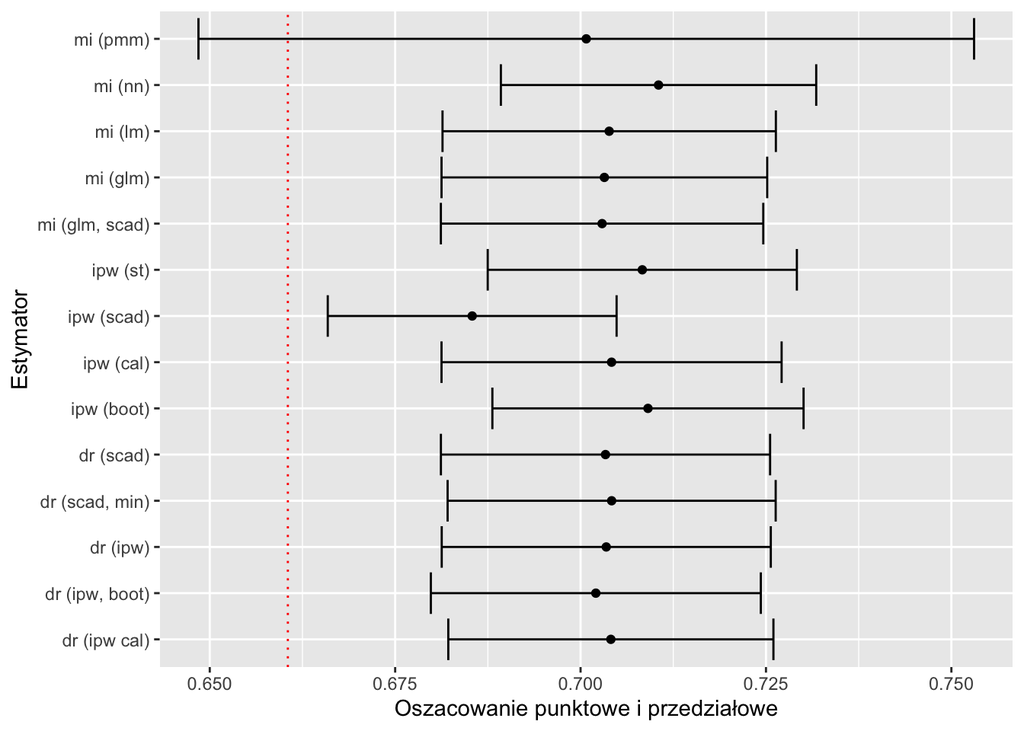

```r
wyniki <- rbind(ipw_summary, mi_summary, dr_summary)

ggplot(data = wyniki, aes(y = est, x = mean, xmin = lower_bound, xmax = upper_bound)) +
  geom_point() +
  geom_vline(xintercept = mean(cbop$jedna_zmiana), linetype = "dotted", color = "red") +
  geom_errorbar() +
  labs(x = "Oszacowanie punktowe i przedziałowe", y = "Estymator")
```